# IODS course project

# RStudio Exercise 3 - Analysis

```r
alc <- read.table("H:/Jatko-opinnot/Open data science/IODS-project/data/alc", sep=",", header=TRUE)
```

Explore the column names and dimensions of the data

```r
colnames(alc)
```

```
##  [1] "X"          "school"     "sex"        "age"        "address"
##  [6] "famsize"    "Pstatus"    "Medu"       "Fedu"       "Mjob"
## [11] "Fjob"       "reason"     "nursery"    "internet"   "guardian"
## [16] "traveltime" "studytime"  "failures"   "schoolsup"  "famsup"
## [21] "paid"       "activities" "higher"     "romantic"   "famrel"
## [26] "freetime"   "goout"      "Dalc"       "Walc"       "health"
## [31] "absences"   "G1"         "G2"         "G3"         "alc_use"
## [36] "high_use"
```

```r
dim(alc)
```

```
## [1] 382  36
```

Data has information about student alcohol consumption. The original data set can be found here: https://archive.ics.uci.edu/ml/datasets/STUDENT+ALCOHOL+CONSUMPTION

There are 382 observations (rows) and 36 variables (columns) in the data. The variables include information about alcohol consumption and also social, gender and study time attributes.

I chose the following 4 variables to study the relationship between them and alcohol consumption level:

14 studytime - weekly study time (numeric: 1 - <2 hours, 2 - 2 to 5 hours, 3 - 5 to 10 hours, or 4 - >10 hours) 19 activities - extra-curricular activities (binary: yes or no) 29 health - current health status (numeric: from 1 - very bad to 5 - very good) 30 absences - number of school absences (numeric: from 0 to 93)

My hypothesis: High weekly study time is associated with low alcohol consumption Having extra-curricular activities is associated with low alcohol consumption Better health is associated with low alcohol consumption The higher the number of absences the larger proportion of students have high alcohol consumption

Tabulate the target variable versus the alcohol consumption

```r
table(high_use = alc$high_use, studytime = alc$studytime)
```

```
##         studytime
## high_use   1   2   3   4
##    FALSE  58 135  52  23
##    TRUE   42  60   8   4
```

```r
table(high_use = alc$high_use, activities = alc$activities)
```

```
##         activities
## high_use  no yes
##    FALSE 122 146
##    TRUE   59  55
```

```r
table(high_use = alc$high_use, health = alc$health)
```

```
##         health
## high_use  1  2  3  4  5
##    FALSE 35 28 62 49 94
##    TRUE  11 16 19 18 50
```

```r
table(high_use = alc$high_use, absences = alc$absences)
```

```
##         absences
## high_use  0  1  2  3  4  5  6  7  8  9 10 11 12 13 14 16 17 18 19 20 21 26
##    FALSE 52 38 42 33 24 16 16  9 14  6  5  2  4  1  1  0  0  1  0  2  1  0
##    TRUE  13 13 16  8 12  6  5  3  6  6  2  4  4  1  6  1  1  1  1  0  1  1
##         absences
## high_use 27 29 44 45
##    FALSE  0  0  0  1
##    TRUE   1  1  1  0
```

Create bar plots for each variable

First access the necesary libraries

```r
library(tidyr); library(dplyr); library(ggplot2)
```

Then initialize a plot of ‘studytime’

```r
g1 <- ggplot(alc, aes(studytime))
```

And draw a bar plot of high_use by studytime

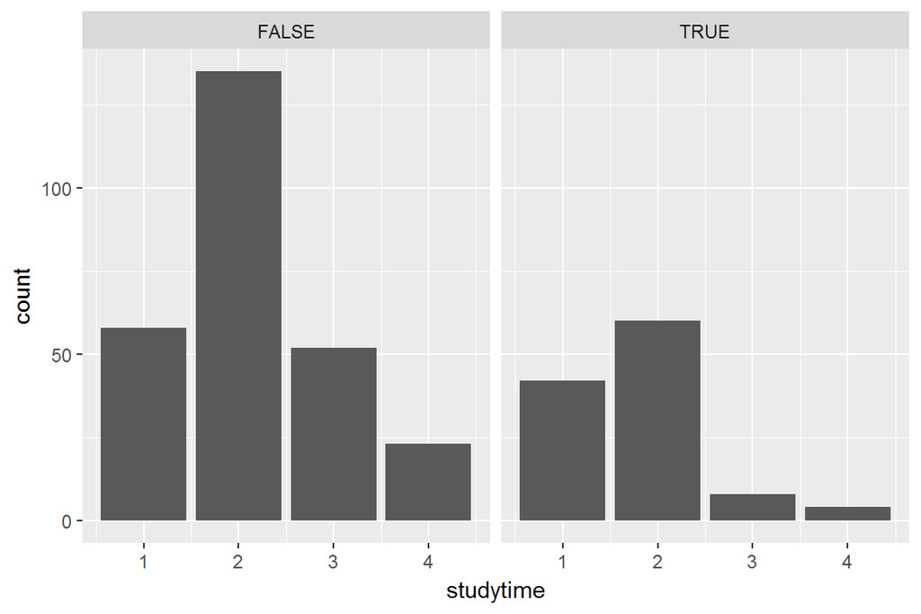

```r
g1 + facet_wrap("high_use") + geom_bar()
```

Do the same for activities, health and absences

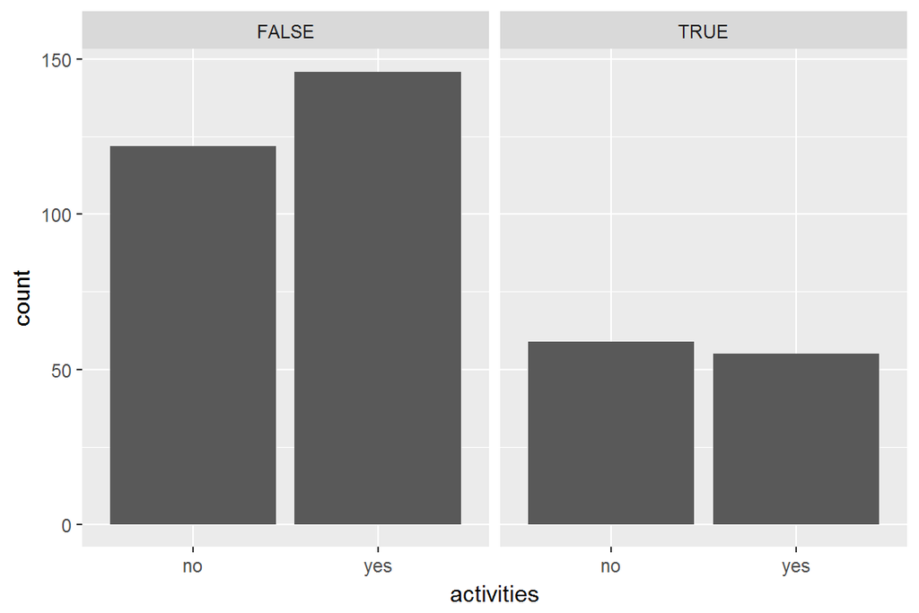

```r
g2 <- ggplot(alc, aes(activities))
g2 + facet_wrap("high_use") + geom_bar()
```

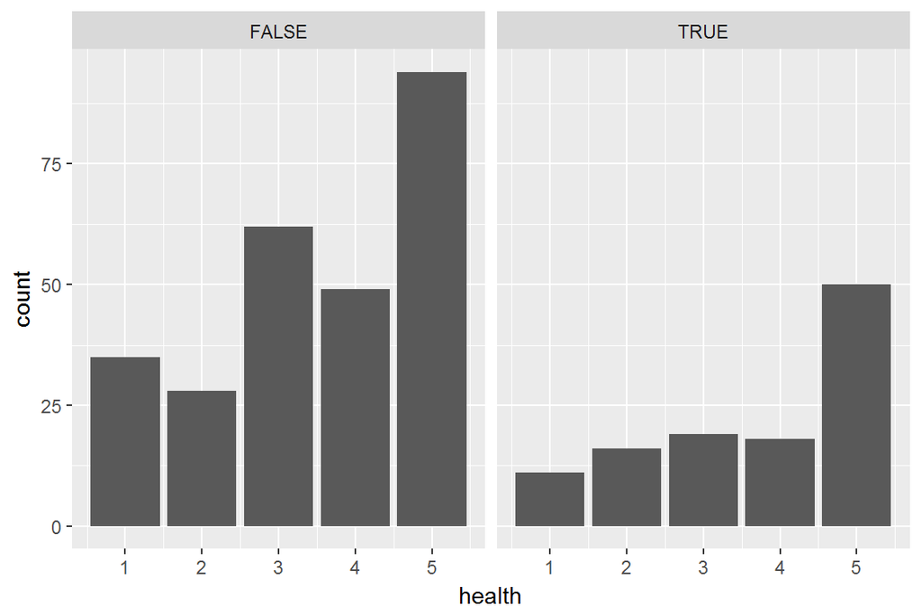

```r
g3 <- ggplot(alc, aes(health))
g3 + facet_wrap("high_use") + geom_bar()
```

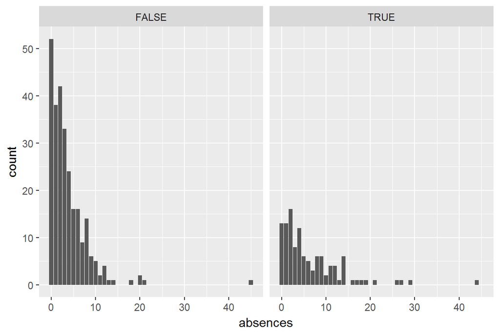

```r
g4 <- ggplot(alc, aes(absences))
g4 + facet_wrap("high_use") + geom_bar()
```

Create box plots

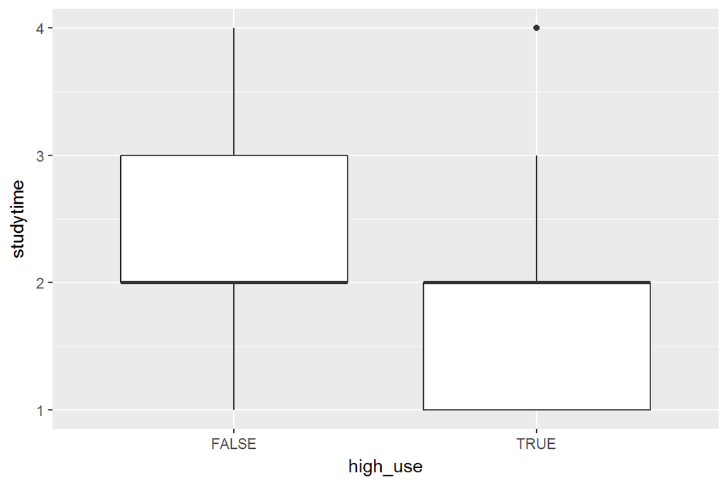

```r
g5 <- ggplot(alc, aes(x = high_use, y = studytime))
g5 + geom_boxplot() + ylab("studytime")
```

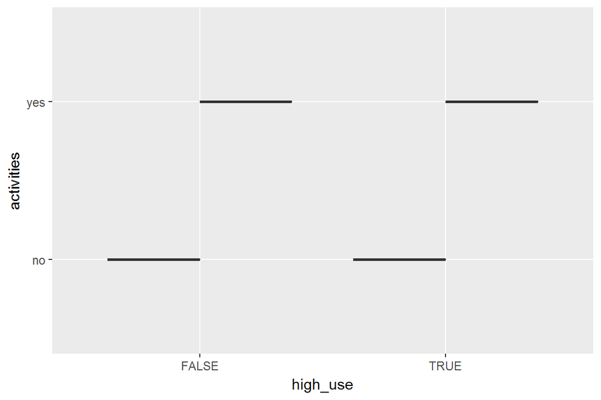

```r
g6 <- ggplot(alc, aes(x = high_use, y = activities))
g6 + geom_boxplot() + ylab("activities")
```

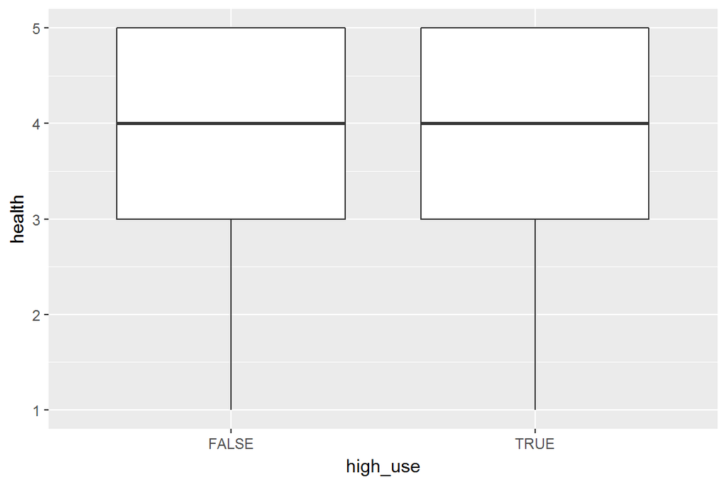

```r
g7 <- ggplot(alc, aes(x = high_use, y = health))
g7 + geom_boxplot() + ylab("health")
```

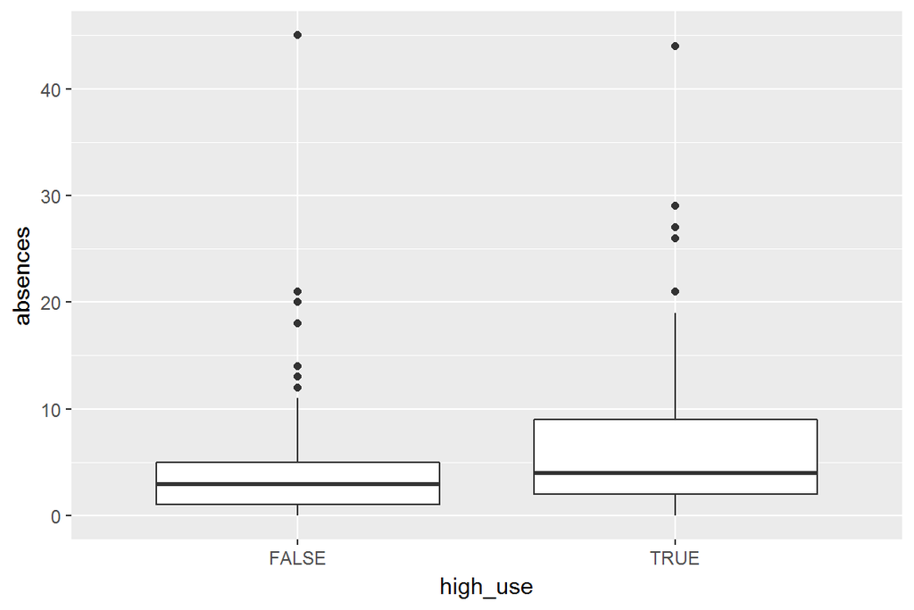

```r
g8 <- ggplot(alc, aes(x = high_use, y = absences))
g8 + geom_boxplot() + ylab("absences")
```

My hypothesis: High weekly study time is associated with low alcohol consumption Result: True: those who had low alcohol consumption studied more.

My hypothesis: Having extra-curricular activities is associated with low alcohol consumption Result: The activities doesn’t seem to affect the level of alcohol consumption

My hypothesis: Better health is associated with low alcohol consumption Result: Health doesn’t seem to affect the level of alcohol consumption

My hypothesis: The higher the number of absences the larger proportion of students have high alcohol consumption Result: True: Students with low alcohol consumption has fewer absences

Logistic regression to statistically explore the relationship between alcohol consumption level and the target variables

Find the model with glm()

```r
m <- glm(high_use ~ studytime + activities + health +absences, data = alc, family = "binomial")
```

Print out a summary of the model

```r
summary(m)
```

```
##
## Call:
## glm(formula = high_use ~ studytime + activities + health + absences,
##     family = "binomial", data = alc)
##
## Deviance Residuals:
##     Min       1Q   Median       3Q      Max
## -2.3062  -0.8378  -0.6616   1.1687   2.1891
##
## Coefficients:
##               Estimate Std. Error z value Pr(>|z|)
## (Intercept)   -0.40990    0.48167  -0.851 0.394770
## studytime     -0.52730    0.15636  -3.372 0.000746 ***
## activitiesyes -0.18653    0.23532  -0.793 0.427986
## health         0.08103    0.08490   0.954 0.339842
## absences       0.08102    0.02281   3.552 0.000382 ***
## ---
## Signif. codes:  0 '***' 0.001 '**' 0.01 '*' 0.05 '.' 0.1 ' ' 1
##
## (Dispersion parameter for binomial family taken to be 1)
##
##     Null deviance: 465.68  on 381  degrees of freedom
## Residual deviance: 432.16  on 377  degrees of freedom
## AIC: 442.16
##
## Number of Fisher Scoring iterations: 4
```

The p-values tell that only studytime and absences have effect on alcohol consumption level. This differs from my hypothesis where I thought that also activities and health would have effect on alcohol consumption level.

Compute the coefficients as odds ratios (OR)

```r
OR <- coef(m) %>% exp
```

Compute confidence intervals (CI)

```r
CI <- confint(m) %>% exp
```

Present the odds ratios with their confidence intervals

```r
cbind(OR, CI)
```

```
##                      OR     2.5 %    97.5 %
## (Intercept)   0.6637136 0.2554830 1.6973858
## studytime     0.5901974 0.4302567 0.7953333
## activitiesyes 0.8298372 0.5226370 1.3167634
## health        1.0844050 0.9196428 1.2838083
## absences      1.0843954 1.0392410 1.1365830
```